# Chapter 3 - Working with Biological Data Structures in R

Sasha Ajay Malkani

2025-12-16

## 1. Overview

A comprehensive overview of key biological data structures used in R will be covered here. Including the following:

- Sequences
- Phylogenetic Trees
- Genomic data
- Practical examples and Coding Techniques

### 1. A. Biological Data Types

- **Sequences** - DNA, RNA and protein sequences are fundamental data types in molecular biology. They are typically represented as strings of nucleotides or amino acids
- **Phylogenetic Trees** - These trees depict evolutionary relationships among species or genes. They are structured into branching diagrams and can be analyzed to study evolution and speciation.
- **Genomic Data** - This includes data derived from whole genomes, such as variants identified through sequencing, gene expression levels, and annotations
- **Transcriptomic Data** - Involving RNA sequencing data, it often requires processing and normalization before analysis.
- **Proteomic Data** - Represents protein sequences, structures, or expression data, useful for understanding biological functions and pathways.

### 1. B. Basic Data Structures in R

The most prominent data structures provided by R include;

- **Vectors** - One-dimensional arrays that hold data of the same type. For example, a vector to hold DNA nucleotide sequences.
- **Lists** - A collection of components that can contain different types of data (including other lists), making them suitable for complex biological data.
- **Data Frames** - Two-dimensional, tabular structures where each column can hold different types of data. Data frames are particularly useful for storing tabular genomic data, such as gene expression values across different samples.
- **Matrices** - Two-dimensional arrays that can contain only one data type. They are often used for numerical data, including statistical analysis of gene expression.
- **S3 and S4 Classes** - The object-oriented programming systems allow for encapsulation and management of more complex biological data types (like phylogenetic trees)

### 1. C. Working with Biological Sequences

The “Biostrings” package from the Bioconductor project used in R is useful for managing nucleotide and protein sequences.

#### 1. C. I. Example - Analyzing DNA Sequences.

```r
# Installing Bioconductor
# if(!requireNamespace("BiocManager", quietly = TRUE))
#   installed.packages("BiocManager")BiocManager::install()

# Install specific bioinformatics Packages
# BiocManager::install("GenomicRanges")

# Loading the Library
library(Biostrings)
# Create a DNA sequence
dna_seq <- DNAString("AGCTTAGCAGTA")
print(dna_seq)
```

```
## 12-letter DNAString object
## seq: AGCTTAGCAGTA
```

```r
# Reverse Complement
rev_comp <- reverseComplement(dna_seq)
print(rev_comp)
```

```
## 12-letter DNAString object
## seq: TACTGCTAAGCT
```

```r
# Find a specific motif
motif <- "AGC"
match <- matchPattern(motif, dna_seq)
print(match)
```

```
## Views on a 12-letter DNAString subject
## subject: AGCTTAGCAGTA
## views:
##       start end width
##   [1]     1   3     3 [AGC]
##   [2]     6   8     3 [AGC]
```

Tasks central to many biological analyses performed here include;

- Creating a DNA sequence
- Computing its reverse complement
- Searching for specific motif

### 1. D. Working with Phylogenetic Trees

Phylogenetic trees can be visualized and manipulated using the “ape” package in R. This package offers tools for tree interpretation and modification.

#### 1. D. I. Example - Creating and Plotting a Phylogenetic Tree.

```r
# Install and load the "ape" package
install.packages("ape", repos = "http://cran.us.r-project.org")
library(ape)
```

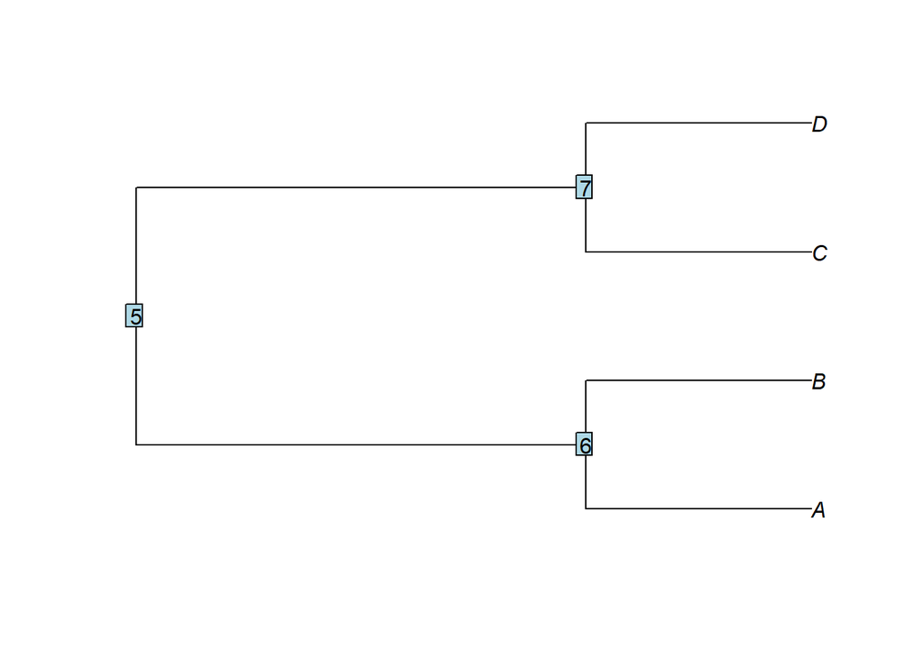

```r
# Create a simple phylogenetic tree
tree <- read.tree(text = "((A,B),(C,D));")
plot(tree)

# Add branch labels
nodelabels()
```

The above code performs the following;

- A basic phylogenetic tree
- Phylogenetic tree visualization
- Addition of branch labels

### 1. E. Handling Genomic Data with “Genomic Ranges”

Genomic data analysis often requires the organization and manipulation of vast ranges of genomic coordinates. The “Genomic Ranges” package helps manage such data efficiently, allowing for the representation of ranges on the genome.

#### 1. E. I. Example - Working with “Genomic Ranges”

```r
# Install and load "Genomic Ranges" package
# if(!requireNamespace("BiocManager", quietly = TRUE))
#   installed.packages("BiocManager")BiocManager::install()

# BiocManager::install("GenomicRanges")

# Load Library
library(GenomicRanges)

# Create Genomic Ranges
gr <- GRanges(seqnames = Rle(c("chr1", "chr1", "chr2")),
              ranges = IRanges(start = c(1, 100, 150), end = c(50, 200, 300)),
              strand = Rle(c("+", "-", "+")))
# Show the genomic ranges
print(gr)
```

```
## GRanges object with 3 ranges and 0 metadata columns:
##       seqnames    ranges strand
##          <Rle> <IRanges>  <Rle>
##   [1]     chr1      1-50      +
##   [2]     chr1   100-200      -
##   [3]     chr2   150-300      +
##   -------
##   seqinfo: 2 sequences from an unspecified genome; no seqlengths
```

- Definition of genomic ranges
- Essential for overlaying different types of genomic data
- e.g. mutations, gene annotations and expression profiles

Ability to handle sequences, trees, and genomic ranges effectively is foundational for research across various fields, from genetics to ecology.

## 2. Understanding Genomic Ranges, Summarized Experiment and Related Classes.

Among these, the **Genomic Ranges** and **Summarized Experiment** classes play a pivotal role in supporting the storage, retrieval, and analysis of genomic features and experimental results. This chapter delves into the structure and functions of these classes, providing a foundation for understanding their applications in genomic data analysis.

### 2. A. The Genomic Ranges Package

#### 2. A. I. Overview

The **Genomic Ranges** package in Bioconductor offers data structures to represent genomic intervals (i.e., regions of DNA, RNA, or other genomic features) and facilitates their manipulation. It is designed for efficient handling and analysis of genomic data, leveraging R’s capabilities to operate on large data sets.

#### 2. A. II. Key Classes

The central class in the **Genomic Ranges** package is “GRanges”, which represents a set of genomic ranges. Let’s explore its components:

- **Seqnames**: The chromosome or sequence name on which the range is located (e.g. “chr1”, “chr2”).
- **Ranges**: The actual start and end positions of the genomic features.
- **Strand**: The DNA strand (“+”, “-”, or “*“) to indicate which side of the double helix the feature lies.
- **Metadata**: Additional annotations or information related to the genomic features (e.g., gene names, descriptions).

#### 2. A. III. Creating GRanges Objects

Creating “GRanges” Object is straightforward. Here’s an example to illustrate:

```r
# Define the genomic ranges
seqnames <- c("chr1", "chr1", "chr2")
start <- c(100, 500, 200)
end <- c(200, 600, 300)
strand <- c("+", "-", "*")

# Create the GRanges object
gr <- GRanges(seqnames = seqnames, ranges = IRanges(start = start, end = end),
              strand = strand)

# Inspect the GRanges object
print(gr)
```

```
## GRanges object with 3 ranges and 0 metadata columns:
##       seqnames    ranges strand
##          <Rle> <IRanges>  <Rle>
##   [1]     chr1   100-200      +
##   [2]     chr1   500-600      -
##   [3]     chr2   200-300      *
##   -------
##   seqinfo: 2 sequences from an unspecified genome; no seqlengths
```

This code creates;

- “GRanges” object
- Containing 3 genomic intervals
- Each associated with specific chromosomes and strands

#### 2. A. IV. Common Operations

The **Genomic Ranges** package provides numerous functions for manipulating genomic ranges, such as;

- **Find Overlaps**: Identify ranges that overlap with others using the “find Overlaps” function.
- **Merge**: Combine overlapping genomic ranges with the “reduce” function.
- **Counts**: Count how many ranges fall within specified genomic intervals.

These operations can be conducted efficiently, making it feasible to analyze large data sets.

### 2. B. Summarized Experiment Class

#### 2. B. I. Overview.

While “GRanges” is focused on genomic features, the **Summarized Experiment** class serves as a data container for storing high-dimensional genomic data, such as count matrices derived from RNA-seq experiments. This class allows researchers to manage both the experiment-level metadata and the genomic features associated with the data.

#### 2. B. II. Structure

A **Summarized Experiment** object contains:

- **Assays**: A list of matrices storing genomic data, typically with rows representing genomic features and columns representing samples.
- **Row Data**: Metadata associated with the rows (features), often in the form of a “Data Frame”.
- **Column Data**: Metadata associated with the columns (samples), also in a “Data Frame”.

#### 2. B. III. Creating Summarized Experiment Objects

Here’s how you can create a **Summarized Experiment** object.

```r
# Load Library
library(SummarizedExperiment)
# Sample Data (rpois = 100 data points - Poisson Dist.(Pd), Lambda = mean of (Pd),
# nrow = 10 rows)
counts <- matrix(rpois(100, lambda = 10), nrow = 10)

# 10 features, 10 samples (gene & sample names)
row_data <- DataFrame(gene_id = paste0("gene", 1:10))

col_data <- DataFrame(sample_id = paste0("sample", 1:10))

# Create the Summarized Experiment object
se <- SummarizedExperiment(assays = list(counts = counts), rowData = row_data,
                           colData = col_data)

# Inspect the object
print(se)
```

```
## class: SummarizedExperiment
## dim: 10 10
## metadata(0):
## assays(1): counts
## rownames: NULL
## rowData names(1): gene_id
## colnames: NULL
## colData names(1): sample_id
```

This creates;

- Summarized Experiment object
- Includes matrix of counts
- Associated metadata

#### 2. B. IV Accessing Data

The **Summarized Experiment** class implements several methods for accessing its components:

- **“assay()”**: Extracts the assay data.
- **“rowData() and colData()”**: Retrieve feature and sample metadata, respectively

Using these methods, one can easily handle complex experimental data, providing a structured interface for analysis.

## 3. Combining GRanges and Summarized Experiment

One of the powerful features of R is the ability to seamlessly integrate different data structures. In genomic studies, you often encounter situations where you need to analyze genomic feature alongside experimental data. This is where combining “GRanges” with “Summarized Experiment” becomes invaluable.

### 3. A. Adding Genomic Ranges to Summarized Experiment

To associate genomic ranges with experimental data, you can use “rowRanges()” to assign “GRanges” object to your **Summarized Experiment**:

```r
# Define the genomic ranges
seqnames <- c("chr1", "chr1", "chr2", "chr1", "chr1", "chr2", "chr1", "chr1", "chr2", "chr2")
start <- c(100, 500, 200, 300, 400, 600, 700, 800, 900, 1000)
end <- c(200, 600, 300, 400, 500, 700, 800, 900, 1000, 1100)
strand <- c("+", "-", "*", "+", "-", "*", "+", "-", "*", "-")

# Create the GRanges object
gr <- GRanges(seqnames = seqnames, ranges = IRanges(start = start, end = end),
              strand = strand)

# Inspect the GRanges object
print(gr)
```

```
## GRanges object with 10 ranges and 0 metadata columns:
##        seqnames    ranges strand
##           <Rle> <IRanges>  <Rle>
##    [1]     chr1   100-200      +
##    [2]     chr1   500-600      -
##    [3]     chr2   200-300      *
##    [4]     chr1   300-400      +
##    [5]     chr1   400-500      -
##    [6]     chr2   600-700      *
##    [7]     chr1   700-800      +
##    [8]     chr1   800-900      -
##    [9]     chr2  900-1000      *
##   [10]     chr2 1000-1100      -
##   -------
##   seqinfo: 2 sequences from an unspecified genome; no seqlengths
```

```r
# Assign GRanges to Summarized Experiment object
rowRanges(se) <- gr
print(rowRanges(se))
```

```
## GRanges object with 10 ranges and 0 metadata columns:
##        seqnames    ranges strand
##           <Rle> <IRanges>  <Rle>
##    [1]     chr1   100-200      +
##    [2]     chr1   500-600      -
##    [3]     chr2   200-300      *
##    [4]     chr1   300-400      +
##    [5]     chr1   400-500      -
##    [6]     chr2   600-700      *
##    [7]     chr1   700-800      +
##    [8]     chr1   800-900      -
##    [9]     chr2  900-1000      *
##   [10]     chr2 1000-1100      -
##   -------
##   seqinfo: 2 sequences from an unspecified genome; no seqlengths
```

This way, the genomic context of the features is embedded directly within the **Summarized Experiment** object, allowing for integrated analyses.

The **Genomic Ranges** and **Summarized Experiment** classes in R provide researchers with powerful tools for managing and analyzing genomic data. The ability yo represent genomic features through “GRanges” and store high-dimensional data in “Summarized Experiment” facilitates complex analyses and aids in deriving meaningful biological insights. Understanding and employing these classes can significantly enhance the conduct of genomic studies, making R a versatile choice for bioinformatics tasks.

## 4. Importing and Managing Biological Data Sets in R

In contemporary biological research, the proficiency to handle, analyze, and visualize large data sets is indispensible. R, a powerful programming language and environment, provides many tools for importing and managing biological data sets. This chapter focuses on how to effectively work with different forms of biological data in R, emphasizing best practices for importing, cleaning, and maintaining data sets for subsequent analysis.

### 4. A. Understanding Biological Data Types

Before diving into the mechanisms of importing biological data sets, it’s crucial to understand the types of data commonly encountered in biological research. Typically, biological data sets can be categorized into the following:

- **Genomic Data**: Sequencing data, SNP data, or gene expression data (often in formats like FASTA, VCF, or TXT).
- **Proteomic Data**: Data pertaining to protein expressions, often stored in formats like CSV or Excel spreadsheets.
- **Metabolomic Data**: Data capturing metabolic profiles, usually structured in tables.
- **Ecological Data**: Information concerning species distributions, environmental variables, etc.

Each data type may come in a distinct format, and R provides specific packages tailored to each of these formats

### 4. B. Importing Data into R

#### 4. B. I. Using Base R Functions

R offers a variety of base functions for importing data. Here are some common approaches:

#### 4. B. I. Using Base R Functions - CSV

- **CSV Files**: The “read.csv()” function is used to load CSV files. The “header” argument specifies whether the first row contains variable names.

```r
data1 <- read.csv("Genomic_Ranges_CSV.csv", header = TRUE, stringsAsFactors = FALSE)
data1
```

```
##    seqnames     ranges strand
## 1      chr1    100-200      +
## 2      chr1    500-600      -
## 3      chr2    200-300      *
## 4      chr1    300-400      +
## 5      chr1    400-500      -
## 6      chr2    600-700      *
## 7      chr1    700-800      +
## 8      chr1    800-900      -
## 9      chr2   900-1000      *
## 10     chr2 1000-1100       -
```

#### 4. B. I. Using Base R Functions - XLSX

- **Excel Files**: Though R does not have built-in functionalities for Excel, additional packages like “readxl” can be utilized.

```r
library(readxl)
data2 <- read_excel("Genomic_Ranges_XLSX.xlsx")
data2
```

```
## # A tibble: 10 × 3
##    seqnames ranges    strand
##    <chr>    <chr>     <chr>
##  1 chr1     100-200   +
##  2 chr1     500-600   -
##  3 chr2     200-300   *
##  4 chr1     300-400   +
##  5 chr1     400-500   -
##  6 chr2     600-700   *
##  7 chr1     700-800   +
##  8 chr1     800-900   -
##  9 chr2     900-1000  *
## 10 chr2     1000-1100 -
```

#### 4. B. I. Using Base R Functions - TEXT

- **Text Files**: The “read.table()” function can be employed for importing tab-delimited text files

```r
data3 <- read.table("Genomic_Ranges_TSV.txt", header = TRUE, sep = "\t",
                   stringsAsFactors = FALSE )
data3
```

```
##    seqnames     ranges strand
## 1      chr1    100-200      +
## 2      chr1    500-600      -
## 3      chr2    200-300      *
## 4      chr1    300-400      +
## 5      chr1    400-500      -
## 6      chr2    600-700      *
## 7      chr1    700-800      +
## 8      chr1    800-900      -
## 9      chr2   900-1000      *
## 10     chr2 1000-1100       -
```

#### 4. B. II. Utilizing Specialized Packages

For specific data types, specialized packages are often more efficient:

- **Bioconductor**: This is a repository of tools for the analysis of genomic data and can handle formats like BAM, VCF and more. The **“Biostrings”** package, for example, facilitates the import and manipulation of DNA sequences.

#### 4. B. II. Utilizing Specialized Packages - “Biostrings” Package

```r
# Load Library
library(Biostrings)

# Read DNA sequence data - FASTA file
dna_sequences <-readDNAStringSet("dna.example.fasta")

# Elements of S4 object of class "DNAStringSet"
dna_sequences@pool
```

```
## SharedRaw_Pool of length 1
## 1: SharedRaw of length 55782 (data starting at address 000002031AC84070)
```

```r
dna_sequences@ranges
```

```
##    group start   end width
## 1      1     1   990   990
## 2      1   991  1714   724
## 3      1  1715  4794  3080
## 4      1  4795  7657  2863
## 5      1  7658 11489  3832
## 6      1 11490 16294  4805
## 7      1 16295 17957  1663
## 8      1 17958 18469   512
## 9      1 18470 19160   691
## 10     1 19161 22232  3072
## 11     1 22233 24033  1801
## 12     1 24034 27636  3603
## 13     1 27637 30114  2478
## 14     1 30115 31722  1608
```

[output cut: 37 more lines]

```r
dna_sequences@elementType
```

```
## [1] "DNAString"
```

```r
dna_sequences@elementMetadata
```

```r
dna_sequences@metadata
```

```
## list()
```

- **tidyverse**: The **“readr”** package from the tidyverse collection provides user-friendly functions such as;

“read_csv()” and “read_tsv()” which are optimized for speed and data integrity.

#### 4. B. II. Utilizing Specialized Packages - “readr” package

```r
# Load library
library(readr)

# Read csv using a function from the "readr" package
data4 <- read_csv("Genomic_Ranges_CSV.csv")
data4
```

```
## # A tibble: 10 × 3
##    seqnames ranges    strand
##    <chr>    <chr>     <chr>
##  1 chr1     100-200   +
##  2 chr1     500-600   -
##  3 chr2     200-300   *
##  4 chr1     300-400   +
##  5 chr1     400-500   -
##  6 chr2     600-700   *
##  7 chr1     700-800   +
##  8 chr1     800-900   -
##  9 chr2     900-1000  *
## 10 chr2     1000-1100 -
```

## 5. Data Cleaning and Management

Once data is imported, cleaning and manageing the data set is crucial to ensure accuracy in analysis. The following steps are foundational:

### 5. A. Exploring the Data

Utilize functions like “head()”, “str” and “summary()” to get an overview of the imported data

```r
head(data4)
```

```
## # A tibble: 6 × 3
##   seqnames ranges  strand
##   <chr>    <chr>   <chr>
## 1 chr1     100-200 +
## 2 chr1     500-600 -
## 3 chr2     200-300 *
## 4 chr1     300-400 +
## 5 chr1     400-500 -
## 6 chr2     600-700 *
```

```r
str(data4)
```

```
## spc_tbl_ [10 × 3] (S3: spec_tbl_df/tbl_df/tbl/data.frame)
##  $ seqnames: chr [1:10] "chr1" "chr1" "chr2" "chr1" ...
##  $ ranges  : chr [1:10] "100-200" "500-600" "200-300" "300-400" ...
##  $ strand  : chr [1:10] "+" "-" "*" "+" ...
##  - attr(*, "spec")=
##   .. cols(
##   ..   seqnames = col_character(),
##   ..   ranges = col_character(),
##   ..   strand = col_character()
##   .. )
##  - attr(*, "problems")=<externalptr>
```

```r
summary(data4)
```

```
##    seqnames            ranges             strand
##  Length:10          Length:10          Length:10
##  Class :character   Class :character   Class :character
##  Mode  :character   Mode  :character   Mode  :character
```

### 5. B. Handling Missing Values

Missing data is a common issue in biological data sets. Use functions like “na.omit()” or “is.na()” to identify and handle missing values.

```r
# Read in data set with missing values
data5 <- read.csv("Genomic_Ranges_CSV_NA.csv", header = TRUE, stringsAsFactors = FALSE)
data5
```

```
##    seqnames     ranges strand
## 1      chr1    100-200      +
## 2      chr1       <NA>      -
## 3      chr2    200-300      *
## 4      chr1    300-400   <NA>
## 5      chr1    400-500      -
## 6      chr2    600-700      *
## 7      chr1    700-800      +
## 8      chr1    800-900   <NA>
## 9      chr2   900-1000      *
## 10     chr2 1000-1100       -
```

```r
# Clean data
data_cleaned <- na.omit(data5)
data_cleaned
```

```
##    seqnames     ranges strand
## 1      chr1    100-200      +
## 3      chr2    200-300      *
## 5      chr1    400-500      -
## 6      chr2    600-700      *
## 7      chr1    700-800      +
## 9      chr2   900-1000      *
## 10     chr2 1000-1100       -
```

### 5. C. Transformation and Normalization

```r
# Load library
library(dplyr)
# Read in data set with numeric data
data6 <- read.csv("Genomic_Ranges_CSV_numeric.csv", header = TRUE, stringsAsFactors = FALSE)
data6
```

```
##    seqnames start  end strand
## 1      chr1   100  200      +
## 2      chr1   500  600      -
## 3      chr2   200  300      *
## 4      chr1   300  400      +
## 5      chr1   400  500      -
## 6      chr2   600  700      *
## 7      chr1   700  800      +
## 8      chr1   800  900      -
## 9      chr2   900 1000      *
## 10     chr2  1000 1100      -
```

```r
# Normalization of numerical columns across the data set
data_normalized <- data6 %>% mutate(across(where(is.numeric), ~ scale(.)))
data_normalized
```

```
##    seqnames      start        end strand
## 1      chr1 -1.4863011 -1.4863011      +
## 2      chr1 -0.1651446 -0.1651446      -
## 3      chr2 -1.1560120 -1.1560120      *
## 4      chr1 -0.8257228 -0.8257228      +
## 5      chr1 -0.4954337 -0.4954337      -
## 6      chr2  0.1651446  0.1651446      *
## 7      chr1  0.4954337  0.4954337      +
## 8      chr1  0.8257228  0.8257228      -
## 9      chr2  1.1560120  1.1560120      *
## 10     chr2  1.4863011  1.4863011      -
```

### 5. D. Formatting and Reshaping Data

Biological data sets may be wide or long format. The “tidyverse” provides “pivot_longer()” and “pivot_wider()” functions that facilitate this transformation.

```r
# Load Library
library(tidyr)
# Read in data set
data6 <- read.csv("Genomic_Ranges_CSV_numeric_ID.csv", header = TRUE, stringsAsFactors = FALSE)
data6
```

```
##    ID seqnames start  end strand
## 1   1     chr1   100  200      +
## 2   2     chr1   500  600      -
## 3   3     chr2   200  300      *
## 4   4     chr1   300  400      +
## 5   5     chr1   400  500      -
## 6   6     chr2   600  700      *
## 7   7     chr1   700  800      +
## 8   8     chr1   800  900      -
## 9   9     chr2   900 1000      *
## 10 10     chr2  1000 1100      -
```

```r
# Conversion of wide data set to a long data set
data_long <- pivot_longer(data6, cols = c("start", "end"),
                          names_to = "variable", values_to = "value")
data_long
```

```
## # A tibble: 20 × 5
##       ID seqnames strand variable value
##    <int> <chr>    <chr>  <chr>    <int>
##  1     1 chr1     "   +" start      100
##  2     1 chr1     "   +" end        200
##  3     2 chr1     "   -" start      500
##  4     2 chr1     "   -" end        600
##  5     3 chr2     "   *" start      200
##  6     3 chr2     "   *" end        300
##  7     4 chr1     "   +" start      300
##  8     4 chr1     "   +" end        400
##  9     5 chr1     "   -" start      400
## 10     5 chr1     "   -" end        500
## 11     6 chr2     "   *" start      600
## 12     6 chr2     "   *" end        700
## 13     7 chr1     "   +" start      700
## 14     7 chr1     "   +" end        800
## 15     8 chr1     "   -" start      800
## 16     8 chr1     "   -" end        900
## 17     9 chr2     "   *" start      900
## 18     9 chr2     "   *" end       1000
## 19    10 chr2     "   -" start     1000
## 20    10 chr2     "   -" end       1100
```

```r
# Conversion of a long data set back to a wide data set
data_wide <- pivot_wider(data_long, names_from = variable,
                         values_from = value)
data_wide
```

```
## # A tibble: 10 × 5
##       ID seqnames strand start   end
##    <int> <chr>    <chr>  <int> <int>
##  1     1 chr1     "   +"   100   200
##  2     2 chr1     "   -"   500   600
##  3     3 chr2     "   *"   200   300
##  4     4 chr1     "   +"   300   400
##  5     5 chr1     "   -"   400   500
##  6     6 chr2     "   *"   600   700
##  7     7 chr1     "   +"   700   800
##  8     8 chr1     "   -"   800   900
##  9     9 chr2     "   *"   900  1000
## 10    10 chr2     "   -"  1000  1100
```

## 6. Managing Large Data Sets

When working with large biological data sets, memory limitations can become an issue. R offers several strategies:

### 6. A. Data Table

The “data.table” package provides an enhanced version of data frames that is more efficient in terms of memory and speed.

```r
# Load Library
library(data.table)
# Read in data set
data7 <- fread("Literature search - complete set.csv")
head(data7, n = 1)
```

[output not shown]

### 6. B. Database Connections

For extremely large data sets, consider using R to connect to databases (e.g. SQLite, MySQL) allowing for efficient data management without loading entire data sets into memory.

```r
# Load Library
# library(DBI)

# con <- dbConnect(RSQLite::SQLite(), "my_database.sqlite")
# data <- dbReadTable(con, "table_name")
```

## 7. Best Practices in Data Management

To ensure the integrity and reproducibility of analyses, adhere to the following best practices:

- **Document Everything**: Keep a detailed log of all data manipulations and analyses, either with comment in the R script or in a separate README file.
- **Regular Backups**: Store data sets and scripts in version-controlled systems (e.g. Git) to track changes and recover older versions as necessary.
- **Automate Processes**: Automate repetitive tasks using functions or scripts to minimize human error and save time.

Importing and managing biological data sets in R requires a comprehensive understanding of data types, the appropriate use of packages and functions, and meticulous data management practices. By mastering these techniques, researchers can significantly enhance the robustness and reliability of their analyses, paving the way for insightful discoveries in the biological sciences

```r
Sys.Date()
```

```
## [1] "2026-01-18"
```